# COMPSCIX 415.2 Homework 6

Mario Casas Gonzalez

July 16, 2018

## Exercise 1

### 1. What variables are in this data set?

According to the help file, the variables are the following:

- outcome | survival status after 20 years: a factor with levels Alive Dead
- smoker | smoking status at baseline: a factor with levels No Yes
- age | age (in years) at the time of the first survey

### 2. How many observations are there and what does each represent?

Ther are 1314 observation on women, representing their age during the first survey, smoking status and survival status after 20 years.

### 3. Create a table (use the R code below as a guide) and a visualization of the relationship between smoking status and outcome, ignoring age. What do you see? Does it make sense?

It doesn’t make sense because it seems to show more smokers survive.

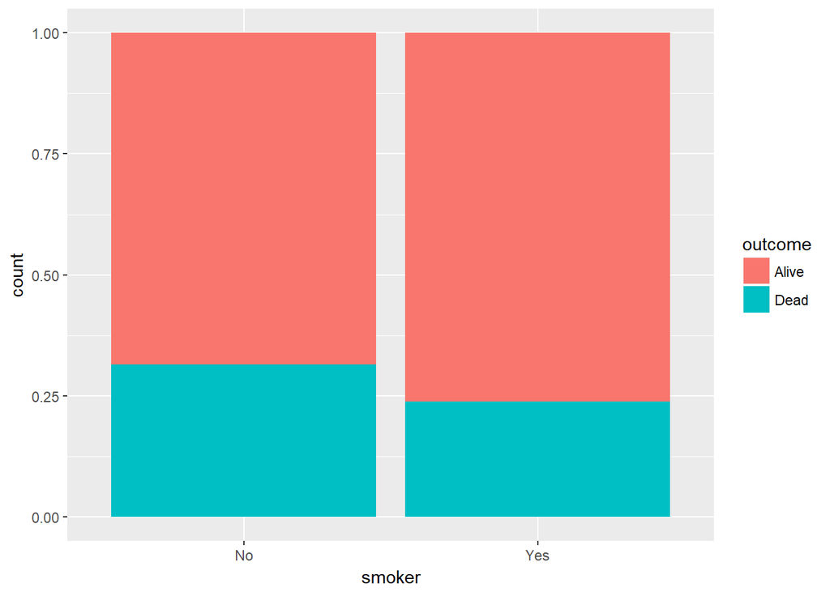

```r
smoking_outcome <- Whickham %>% count(smoker,outcome)
smoking_outcome <- smoking_outcome %>% spread (key=outcome,value=n)
ggplot(Whickham,aes(smoker))+geom_bar(mapping=aes(fill=outcome), position="fill")
```

### 4. Recode the age variable into an ordered factor with three categories: age <= 44, age > 44 & age <= 64, and age > 64. Now, recreate visualization from above, but facet on your new age factor. What do you see? Does it make sense?

```r
age_fact <- factor(Whickham$age,ordered=TRUE)
age_fact <- factor(levels=c('young','middle_age','old'))
age_fact <- case_when(Whickham$age<=44 ~'young', Whickham$age>44 & Whickham$age<=64 ~ 'middle_age', Whickham$age>64 ~'senior')
age_fact <- fct_relevel(age_fact, 'young','middle_age','senior')
Whickham_cat <- Whickham %>% mutate(age_fact)
Whickham_cat %>% count(age_fact, smoker, outcome)
```

```
## # A tibble: 12 x 4
##    age_fact   smoker outcome     n
##    <fct>      <fct>  <fct>   <int>
##  1 young      No     Alive     327
##  2 young      No     Dead       12
##  3 young      Yes    Alive     270
##  4 young      Yes    Dead       15
##  5 middle_age No     Alive     147
##  6 middle_age No     Dead       53
##  7 middle_age Yes    Alive     167
##  8 middle_age Yes    Dead       80
##  9 senior     No     Alive      28
## 10 senior     No     Dead      165
## 11 senior     Yes    Alive       6
## 12 senior     Yes    Dead       44
```

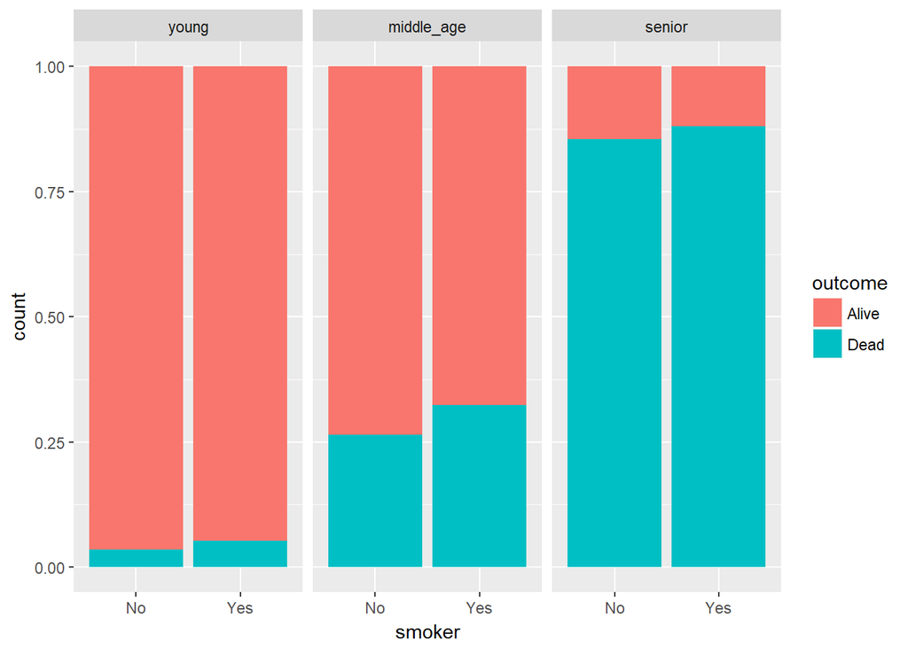

```r
ggplot(Whickham_cat,aes(smoker))+geom_bar(mapping=aes(fill=outcome), position="fill") + facet_grid(~age_fact)
```

## Exercise 2

### 1. Generate a random sample of size n = 10000 from a gamma(1,2) distribution and plot a histogram or density curve. Use the code below to help you get your sample.

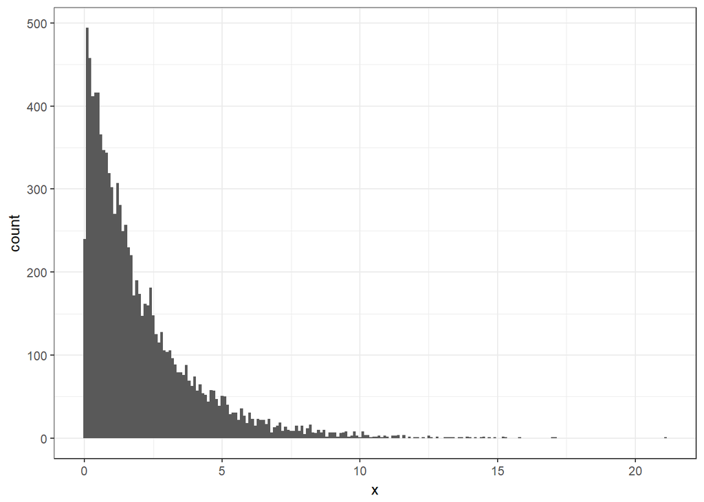

```r
 n <- 10000
gamma_samp <- tibble(x = rgamma(n, shape = 1, scale = 2))
gamma_samp %>% ggplot() + geom_histogram(aes(x = x), binwidth = 0.1) + theme_bw()
```

```r
mean_samp <- gamma_samp %>% .[['x']] %>% mean()
mean_samp
```

```
## [1] 2.004268
```

```r
sd_samp <- gamma_samp %>% .[['x']] %>% sd()
sd_samp
```

```
## [1] 2.046705
```

### 3. Pretend the distribution of our population of data looks like the plot above. Now take a sample of size n = 30 from a Gamma(1,2) distribution, plot the histogram or density curve, and calculate the mean and standard deviation.

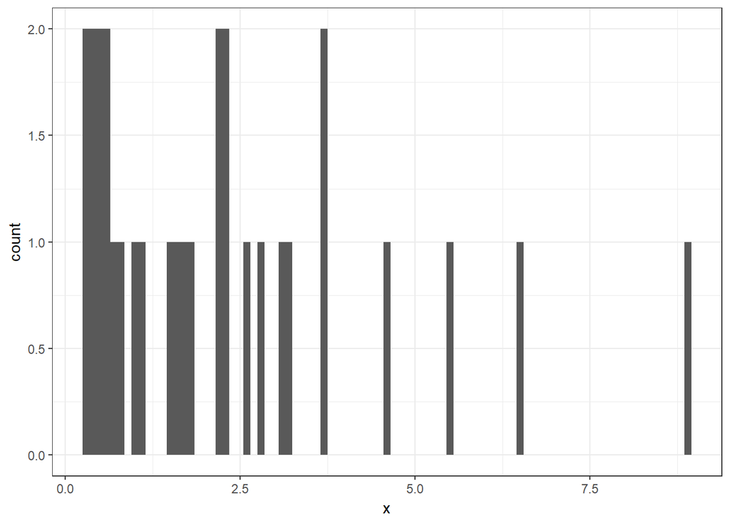

```r
gamma_samp_30 <- gamma_samp %>% sample_n(30)
gamma_samp_30 %>% ggplot() + geom_histogram(aes(x = x), binwidth = 0.1) + theme_bw()
```

```r
mean_samp_30 <- gamma_samp_30 %>% .[['x']] %>% mean()
mean_samp_30
```

```
## [1] 2.237346
```

```r
sd_samp_30 <- gamma_samp_30 %>% .[['x']] %>% sd()
sd_samp_30
```

```
## [1] 2.024568
```

### 4. Take a sample of size n = 30, again from the Gamma(1,2) distribution, calculate the mean, and assign it to a vector named mean_samp. Repeat this 10000 times!!!! The code below might help.

```r
mean_samp <- rep(NA, 10000)
for(i in 1:10000) {
g_samp <- rgamma(30, shape = 1, scale = 2)
mean_samp[i] <- mean(g_samp)
}
mean_samp <- tibble(mean_samp)
```

### 5. Make a histogram of your collection of means from above (mean_samp).

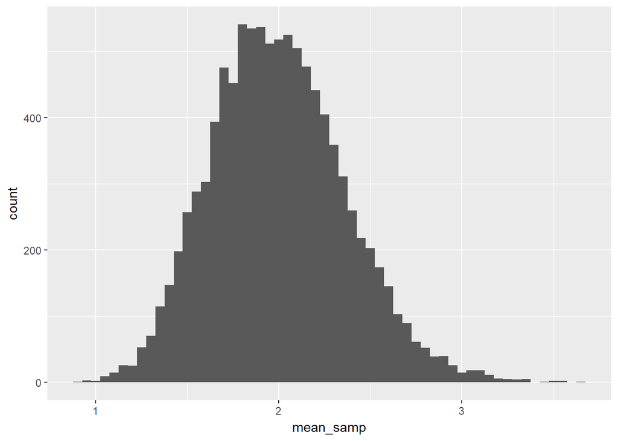

```r
mean_samp %>% ggplot() + geom_histogram(mapping=aes(x=mean_samp),binwidth = 0.05)
```

### 6. Calculate the mean and standard deviation of all of your sample means.

```r
series_mean <- mean_samp %>% .[['mean_samp']] %>% mean()
series_mean
```

```
## [1] 1.998128
```

```r
series_sd <- mean_samp %>% .[['mean_samp']] %>% sd()
series_sd
```

```
## [1] 0.3666563
```

### 7. Did anything surprise you about your answers to #6?

Yes, standard deviation decreased significantly.

### 8. Repeat #4-#6, but now with a sample of size n = 300 instead. Do your results match up well with the theorem?

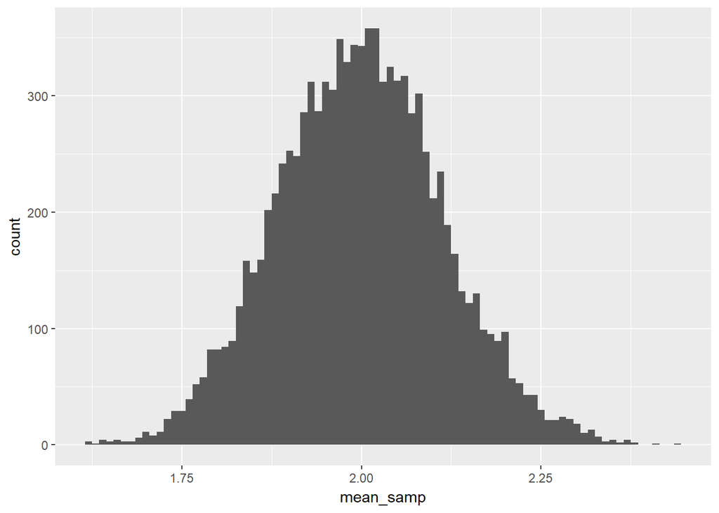

```r
mean_samp <- rep(NA, 10000)
for(i in 1:10000) {
g_samp <- rgamma(300, shape = 1, scale = 2)
mean_samp[i] <- mean(g_samp)
}
mean_samp <- tibble(mean_samp)
mean_samp %>% ggplot() + geom_histogram(mapping=aes(x=mean_samp),binwidth = 0.01)
```

```r
series_mean <- mean_samp %>% .[['mean_samp']] %>% mean()
series_mean
```

```
## [1] 1.998557
```

```r
series_sd <- mean_samp %>% .[['mean_samp']] %>% sd()
series_sd
```

```
## [1] 0.1146654
```